# How Can a Wellness Technology Company Play It Smart?

Adedotun Charles Adegunju

1/17/2022

# Step 1: Ask

## Business Task

Gaining insights into how people are using smart devices to provide high-level recommendations for how these trends can inform marketing strategy.

# Step 2: Prepare

## Data Source

# Step 3: Process

## Installing and loading packages and libraries

## Importing Datasets

```r
daily_activity <- read.csv("../data/dailyActivity_merged.csv")
daily_calories <- read.csv("../data/dailyCalories_merged.csv")
daily_intensities <- read.csv("../data/dailyIntensities_merged.csv")
daily_steps <- read.csv("../data/dailySteps_merged.csv")
heartrate_seconds <- read.csv("../data/heartrate_seconds_merged.csv")
hourly_calories <- read.csv("../data/hourlyCalories_merged.csv")
hourly_intensities <- read.csv("../data/hourlyIntensities_merged.csv")
hourly_steps <- read.csv("../data/hourlySteps_merged.csv")
minute_calories_narrow <- read.csv("../data/minuteCaloriesNarrow_merged.csv")
minute_calories_wide <- read.csv("../data/minutecaloriesWide_merged.csv")
minute_instensities_narrow <- read.csv("../data/minuteIntensitiesNarrow_merged.csv")
minute_instensities_nwide <- read.csv("../data/MinuteIntensitiesWide_merged.csv")
minute_mets_narrow <- read.csv("../data/minuteMETsNarrow_merged.csv")
minute_sleep <- read.csv("../data/minuteSleep_merged.csv")
minute_steps_narrow <- read.csv("../data/minuteStepsNarrow_merged.csv")
minute_steps_wide <- read.csv("../data/minuteStepsWide_merged.csv")
sleep_day <- read.csv("../data/sleepDay_merged.csv")
weight_log_info <- read.csv("../data/weightLogInfo_merged.csv")
```

## Exploring a few key tables

### Daily Activity

```r
str(daily_activity)
```

```
## 'data.frame':    940 obs. of  15 variables:
##  $ Id                      : num  1.5e+09 1.5e+09 1.5e+09 1.5e+09 1.5e+09 ...
##  $ ActivityDate            : chr  "4/12/2016" "4/13/2016" "4/14/2016" "4/15/2016" ...
##  $ TotalSteps              : int  13162 10735 10460 9762 12669 9705 13019 15506 10544 9819 ...
##  $ TotalDistance           : num  8.5 6.97 6.74 6.28 8.16 ...
##  $ TrackerDistance         : num  8.5 6.97 6.74 6.28 8.16 ...
##  $ LoggedActivitiesDistance: num  0 0 0 0 0 0 0 0 0 0 ...
##  $ VeryActiveDistance      : num  1.88 1.57 2.44 2.14 2.71 ...
##  $ ModeratelyActiveDistance: num  0.55 0.69 0.4 1.26 0.41 ...
##  $ LightActiveDistance     : num  6.06 4.71 3.91 2.83 5.04 ...
##  $ SedentaryActiveDistance : num  0 0 0 0 0 0 0 0 0 0 ...
##  $ VeryActiveMinutes       : int  25 21 30 29 36 38 42 50 28 19 ...
##  $ FairlyActiveMinutes     : int  13 19 11 34 10 20 16 31 12 8 ...
##  $ LightlyActiveMinutes    : int  328 217 181 209 221 164 233 264 205 211 ...
##  $ SedentaryMinutes        : int  728 776 1218 726 773 539 1149 775 818 838 ...
##  $ Calories                : int  1985 1797 1776 1745 1863 1728 1921 2035 1786 1775 ...
```

```r
# explore steps, distance and sedentary minutes
daily_activity %>%
  select(TotalSteps, TotalDistance, SedentaryMinutes) %>%
  summary()
```

```
##    TotalSteps    TotalDistance    SedentaryMinutes
##  Min.   :    0   Min.   : 0.000   Min.   :   0.0
##  1st Qu.: 3790   1st Qu.: 2.620   1st Qu.: 729.8
##  Median : 7406   Median : 5.245   Median :1057.5
##  Mean   : 7638   Mean   : 5.490   Mean   : 991.2
##  3rd Qu.:10727   3rd Qu.: 7.713   3rd Qu.:1229.5
##  Max.   :36019   Max.   :28.030   Max.   :1440.0
```

```r
# explore number of active minutes per category
daily_activity %>%
  select(VeryActiveMinutes, FairlyActiveMinutes, LightlyActiveMinutes) %>%
  summary()
```

```
##  VeryActiveMinutes FairlyActiveMinutes LightlyActiveMinutes
##  Min.   :  0.00    Min.   :  0.00      Min.   :  0.0
##  1st Qu.:  0.00    1st Qu.:  0.00      1st Qu.:127.0
##  Median :  4.00    Median :  6.00      Median :199.0
##  Mean   : 21.16    Mean   : 13.56      Mean   :192.8
##  3rd Qu.: 32.00    3rd Qu.: 19.00      3rd Qu.:264.0
##  Max.   :210.00    Max.   :143.00      Max.   :518.0
```

#### Discoveries:

- Average total steps per day are 7638 which a little bit less for having health benefits for according to the CDC research. They found that taking 8,000 steps per day was associated with a 51% lower risk for all-cause mortality (or death from all causes). Taking 12,000 steps per day was associated with a 65% lower risk compared with taking 4,000 steps.
- Average sedentary time is 991 minutes(16 hours), needs to be reduced.

### Sleep Day

```r
str(sleep_day)
```

```
## 'data.frame':    413 obs. of  5 variables:
##  $ Id                : num  1.5e+09 1.5e+09 1.5e+09 1.5e+09 1.5e+09 ...
##  $ SleepDay          : chr  "4/12/2016 12:00:00 AM" "4/13/2016 12:00:00 AM" "4/15/2016 12:00:00 AM" "4/16/2016 12:00:00 AM" ...
##  $ TotalSleepRecords : int  1 2 1 2 1 1 1 1 1 1 ...
##  $ TotalMinutesAsleep: int  327 384 412 340 700 304 360 325 361 430 ...
##  $ TotalTimeInBed    : int  346 407 442 367 712 320 377 364 384 449 ...
```

```r
# explore sleep records, minutes asleep and time in bed
sleep_day %>%
  select(TotalSleepRecords, TotalMinutesAsleep, TotalTimeInBed) %>%
  summary()
```

```
##  TotalSleepRecords TotalMinutesAsleep TotalTimeInBed
##  Min.   :1.000     Min.   : 58.0      Min.   : 61.0
##  1st Qu.:1.000     1st Qu.:361.0      1st Qu.:403.0
##  Median :1.000     Median :433.0      Median :463.0
##  Mean   :1.119     Mean   :419.5      Mean   :458.6
##  3rd Qu.:1.000     3rd Qu.:490.0      3rd Qu.:526.0
##  Max.   :3.000     Max.   :796.0      Max.   :961.0
```

### Hourly Calories

```r
str(hourly_calories)
```

```
## 'data.frame':    22099 obs. of  3 variables:
##  $ Id          : num  1.5e+09 1.5e+09 1.5e+09 1.5e+09 1.5e+09 ...
##  $ ActivityHour: chr  "4/12/2016 12:00:00 AM" "4/12/2016 1:00:00 AM" "4/12/2016 2:00:00 AM" "4/12/2016 3:00:00 AM" ...
##  $ Calories    : int  81 61 59 47 48 48 48 47 68 141 ...
```

### Hourly Steps

```r
str(hourly_steps)
```

```
## 'data.frame':    22099 obs. of  3 variables:
##  $ Id          : num  1.5e+09 1.5e+09 1.5e+09 1.5e+09 1.5e+09 ...
##  $ ActivityHour: chr  "4/12/2016 12:00:00 AM" "4/12/2016 1:00:00 AM" "4/12/2016 2:00:00 AM" "4/12/2016 3:00:00 AM" ...
##  $ StepTotal   : int  373 160 151 0 0 0 0 0 250 1864 ...
```

### Hourly Intensities

```r
str(hourly_intensities)
```

```
## 'data.frame':    22099 obs. of  4 variables:
##  $ Id              : num  1.5e+09 1.5e+09 1.5e+09 1.5e+09 1.5e+09 ...
##  $ ActivityHour    : chr  "4/12/2016 12:00:00 AM" "4/12/2016 1:00:00 AM" "4/12/2016 2:00:00 AM" "4/12/2016 3:00:00 AM" ...
##  $ TotalIntensity  : int  20 8 7 0 0 0 0 0 13 30 ...
##  $ AverageIntensity: num  0.333 0.133 0.117 0 0 ...
```

### Daily Steps

```r
str(daily_steps)
```

```
## 'data.frame':    940 obs. of  3 variables:
##  $ Id         : num  1.5e+09 1.5e+09 1.5e+09 1.5e+09 1.5e+09 ...
##  $ ActivityDay: chr  "4/12/2016" "4/13/2016" "4/14/2016" "4/15/2016" ...
##  $ StepTotal  : int  13162 10735 10460 9762 12669 9705 13019 15506 10544 9819 ...
```

### Daily Calories

```r
str(daily_calories)
```

```
## 'data.frame':    940 obs. of  3 variables:
##  $ Id         : num  1.5e+09 1.5e+09 1.5e+09 1.5e+09 1.5e+09 ...
##  $ ActivityDay: chr  "4/12/2016" "4/13/2016" "4/14/2016" "4/15/2016" ...
##  $ Calories   : int  1985 1797 1776 1745 1863 1728 1921 2035 1786 1775 ...
```

### Daily Intensitiues

```r
str(daily_intensities)
```

```
## 'data.frame':    940 obs. of  10 variables:
##  $ Id                      : num  1.5e+09 1.5e+09 1.5e+09 1.5e+09 1.5e+09 ...
##  $ ActivityDay             : chr  "4/12/2016" "4/13/2016" "4/14/2016" "4/15/2016" ...
##  $ SedentaryMinutes        : int  728 776 1218 726 773 539 1149 775 818 838 ...
##  $ LightlyActiveMinutes    : int  328 217 181 209 221 164 233 264 205 211 ...
##  $ FairlyActiveMinutes     : int  13 19 11 34 10 20 16 31 12 8 ...
##  $ VeryActiveMinutes       : int  25 21 30 29 36 38 42 50 28 19 ...
##  $ SedentaryActiveDistance : num  0 0 0 0 0 0 0 0 0 0 ...
##  $ LightActiveDistance     : num  6.06 4.71 3.91 2.83 5.04 ...
##  $ ModeratelyActiveDistance: num  0.55 0.69 0.4 1.26 0.41 ...
##  $ VeryActiveDistance      : num  1.88 1.57 2.44 2.14 2.71 ...
```

### Weight Log Info

```r
str(weight_log_info)
```

```
## 'data.frame':    67 obs. of  8 variables:
##  $ Id            : num  1.50e+09 1.50e+09 1.93e+09 2.87e+09 2.87e+09 ...
##  $ Date          : chr  "5/2/2016 11:59:59 PM" "5/3/2016 11:59:59 PM" "4/13/2016 1:08:52 AM" "4/21/2016 11:59:59 PM" ...
##  $ WeightKg      : num  52.6 52.6 133.5 56.7 57.3 ...
##  $ WeightPounds  : num  116 116 294 125 126 ...
##  $ Fat           : int  22 NA NA NA NA 25 NA NA NA NA ...
##  $ BMI           : num  22.6 22.6 47.5 21.5 21.7 ...
##  $ IsManualReport: chr  "True" "True" "False" "True" ...
##  $ LogId         : num  1.46e+12 1.46e+12 1.46e+12 1.46e+12 1.46e+12 ...
```

```r
# explore weight and BMI
weight_log_info %>%
  select(WeightKg, BMI) %>%
  summary()
```

```
##     WeightKg           BMI
##  Min.   : 52.60   Min.   :21.45
##  1st Qu.: 61.40   1st Qu.:23.96
##  Median : 62.50   Median :24.39
##  Mean   : 72.04   Mean   :25.19
##  3rd Qu.: 85.05   3rd Qu.:25.56
##  Max.   :133.50   Max.   :47.54
```

## Data Cleaning & Manipulation

### Hourly Calories

```r
# convert ActivityHour column into datetime and create new column "ActivityDatime" with result
hourly_calories$ActivityDatetime <- as.POSIXct(hourly_calories$ActivityHour, format="%m/%d/%Y %I:%M:%S %p")
# extract hour from ActivityDatetime and create new column "Hour" with result
hourly_calories$Hour <- format(hourly_calories$ActivityDatetime, format = "%H")
str(hourly_calories)
```

```
## 'data.frame':    22099 obs. of  5 variables:
##  $ Id              : num  1.5e+09 1.5e+09 1.5e+09 1.5e+09 1.5e+09 ...
##  $ ActivityHour    : chr  "4/12/2016 12:00:00 AM" "4/12/2016 1:00:00 AM" "4/12/2016 2:00:00 AM" "4/12/2016 3:00:00 AM" ...
##  $ Calories        : int  81 61 59 47 48 48 48 47 68 141 ...
##  $ ActivityDatetime: POSIXct, format: "2016-04-12 00:00:00" "2016-04-12 01:00:00" ...
##  $ Hour            : chr  "00" "01" "02" "03" ...
```

### Hourly Steps

```r
# convert ActivityHour column into datetime and create new column "ActivityDatime" with result
hourly_steps$ActivityDatetime <- as.POSIXct(hourly_steps$ActivityHour, format="%m/%d/%Y %I:%M:%S %p")
# extract hour from ActivityDatetime and create new column "Hour" with result
hourly_steps$Hour <- format(hourly_steps$ActivityDatetime, format = "%H")
str(hourly_steps)
```

```
## 'data.frame':    22099 obs. of  5 variables:
##  $ Id              : num  1.5e+09 1.5e+09 1.5e+09 1.5e+09 1.5e+09 ...
##  $ ActivityHour    : chr  "4/12/2016 12:00:00 AM" "4/12/2016 1:00:00 AM" "4/12/2016 2:00:00 AM" "4/12/2016 3:00:00 AM" ...
##  $ StepTotal       : int  373 160 151 0 0 0 0 0 250 1864 ...
##  $ ActivityDatetime: POSIXct, format: "2016-04-12 00:00:00" "2016-04-12 01:00:00" ...
##  $ Hour            : chr  "00" "01" "02" "03" ...
```

### Hourly Intensities

```r
# convert ActivityHour column into datetime and create new column "ActivityDatime" with result
hourly_intensities$ActivityDatetime <- as.POSIXct(hourly_intensities$ActivityHour, format="%m/%d/%Y %I:%M:%S %p")
# extract hour from ActivityDatetime and create new column "Hour" with result
hourly_intensities$Hour <- format(hourly_intensities$ActivityDatetime, format = "%H")
str(hourly_intensities)
```

```
## 'data.frame':    22099 obs. of  6 variables:
##  $ Id              : num  1.5e+09 1.5e+09 1.5e+09 1.5e+09 1.5e+09 ...
##  $ ActivityHour    : chr  "4/12/2016 12:00:00 AM" "4/12/2016 1:00:00 AM" "4/12/2016 2:00:00 AM" "4/12/2016 3:00:00 AM" ...
##  $ TotalIntensity  : int  20 8 7 0 0 0 0 0 13 30 ...
##  $ AverageIntensity: num  0.333 0.133 0.117 0 0 ...
##  $ ActivityDatetime: POSIXct, format: "2016-04-12 00:00:00" "2016-04-12 01:00:00" ...
##  $ Hour            : chr  "00" "01" "02" "03" ...
```

## Merging Data

### Hourly Steps, Intensities & Calories

```r
n_distinct(hourly_steps$Id)
```

```
## [1] 33
```

```r
n_distinct(hourly_calories$Id)
```

```
## [1] 33
```

```r
n_distinct(hourly_intensities$Id)
```

```
## [1] 33
```

```r
# merge hourly_steps and hourly_calories
hourly_sc <- merge(hourly_steps, hourly_calories, by=c("Id", "ActivityDatetime", "ActivityHour", "Hour"))
# merge with hourly_intensities
hourly_sci <- merge(hourly_sc, hourly_intensities, by=c("Id", "ActivityDatetime", "ActivityHour", "Hour"))
# drop "ActivityHour"
hourly_sci <- subset(hourly_sci, select = -c(ActivityHour))
summary(hourly_sci)
```

```
##        Id            ActivityDatetime                  Hour
##  Min.   :1.504e+09   Min.   :2016-04-12 00:00:00   Length:22099
##  1st Qu.:2.320e+09   1st Qu.:2016-04-19 01:00:00   Class :character
##  Median :4.445e+09   Median :2016-04-26 06:00:00   Mode  :character
##  Mean   :4.848e+09   Mean   :2016-04-26 11:46:42
##  3rd Qu.:6.962e+09   3rd Qu.:2016-05-03 19:00:00
##  Max.   :8.878e+09   Max.   :2016-05-12 15:00:00
##    StepTotal          Calories      TotalIntensity   AverageIntensity
##  Min.   :    0.0   Min.   : 42.00   Min.   :  0.00   Min.   :0.0000
##  1st Qu.:    0.0   1st Qu.: 63.00   1st Qu.:  0.00   1st Qu.:0.0000
##  Median :   40.0   Median : 83.00   Median :  3.00   Median :0.0500
##  Mean   :  320.2   Mean   : 97.39   Mean   : 12.04   Mean   :0.2006
##  3rd Qu.:  357.0   3rd Qu.:108.00   3rd Qu.: 16.00   3rd Qu.:0.2667
##  Max.   :10554.0   Max.   :948.00   Max.   :180.00   Max.   :3.0000
```

```r
n_distinct(sleep_day$Id)
```

```
## [1] 24
```

```r
n_distinct(daily_activity$Id)
```

```
## [1] 33
```

```r
nrow(sleep_day)
```

```
## [1] 413
```

```r
nrow(daily_activity)
```

```
## [1] 940
```

# Step 4: Analyze

## Pivot Tables

### Hourly Activities

```r
# each user's hourly activities
hourly_user <- hourly_sci %>%
  group_by(Id, Hour) %>%
  summarize(average_steps = mean(StepTotal), average_intensities = mean(TotalIntensity), average_calories = mean(Calories))
# hourly activity distribution
hourly_general <- hourly_user %>%
  group_by(Hour) %>%
  summarize(average_steps = mean(average_steps), average_intensities = mean(average_intensities), average_calories = mean(average_calories))
```

### Sleep

```r
# each user's sleep pattern
sleep_day_pu <- sleep_day %>%
  group_by(Id) %>%
  summarize(entries = n(), average_InBed = mean(TotalTimeInBed), average_Asleep = mean(TotalMinutesAsleep))
# get number of hours each user sleep for per day
sleep_day_pu$hoursAsleep = sleep_day_pu$average_Asleep / 60
sleep_day_pu$hoursInBed = sleep_day_pu$average_InBed / 60
# get insight into each user's sleep activity
sleep_day_pu %>%
  select(hoursAsleep, hoursInBed) %>%
  summary()
```

```
##   hoursAsleep       hoursInBed
##  Min.   : 1.017   Min.   : 1.150
##  1st Qu.: 5.605   1st Qu.: 6.284
##  Median : 6.985   Median : 7.465
##  Mean   : 6.294   Mean   : 7.002
##  3rd Qu.: 7.488   3rd Qu.: 8.089
##  Max.   :10.867   Max.   :16.017
```

## Visualization

### Sleep Patterns

#### Average number of hours asleep per day for each user

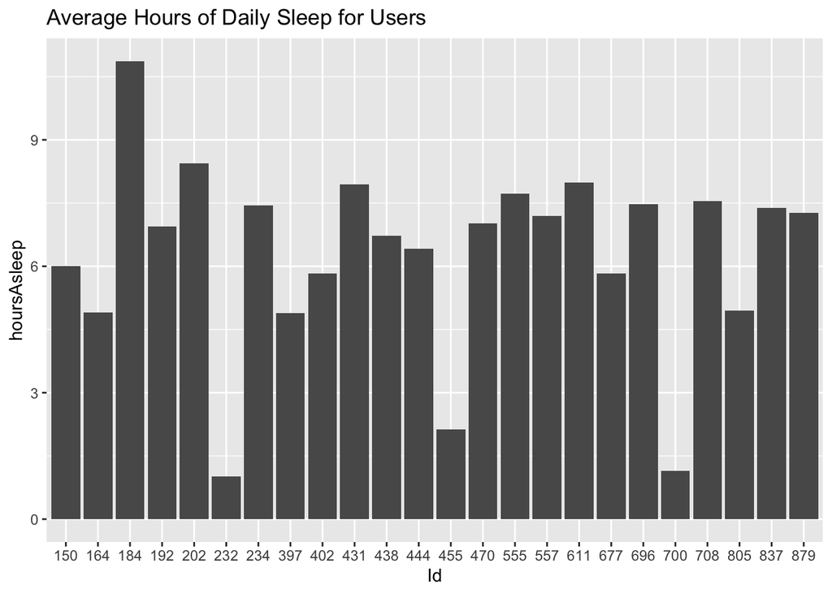

```r
# convert Id to character
sleep_day_pu$Id <- as.character(sleep_day_pu$Id)
sleep_day_pu$Id <- strtrim(sleep_day_pu$Id, 3)
ggplot(sleep_day_pu, aes(x = Id, y = hoursAsleep)) +
  geom_bar(stat = "identity") +
  labs(title = "Average Hours of Daily Sleep for Users")
```

##### We can observe that some users are not getting enough hours of sleep which is 7-9 hours for adults as recommended by WHO.

### Hourly activities for all users

#### Avergae Steps

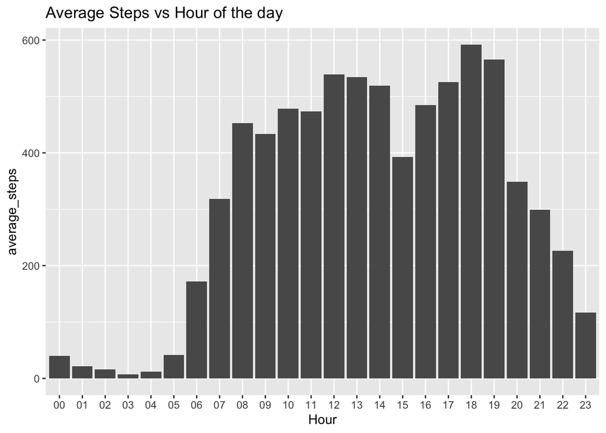

```r
ggplot(hourly_general, aes(x=Hour, y=average_steps)) +
  geom_bar(stat = "identity") +
  labs(title="Average Steps vs Hour of the day")
```

#### Average Instensities

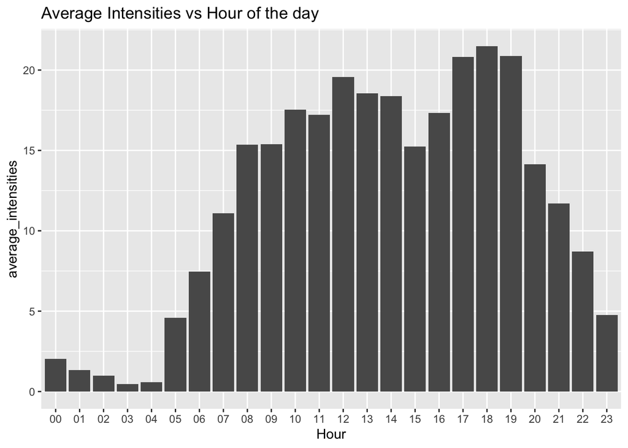

```r
ggplot(hourly_general, aes(x=Hour, y=average_intensities)) +
  geom_bar(stat = "identity") +
  labs(title = "Average Intensities vs Hour of the day")
```

#### Average Calories

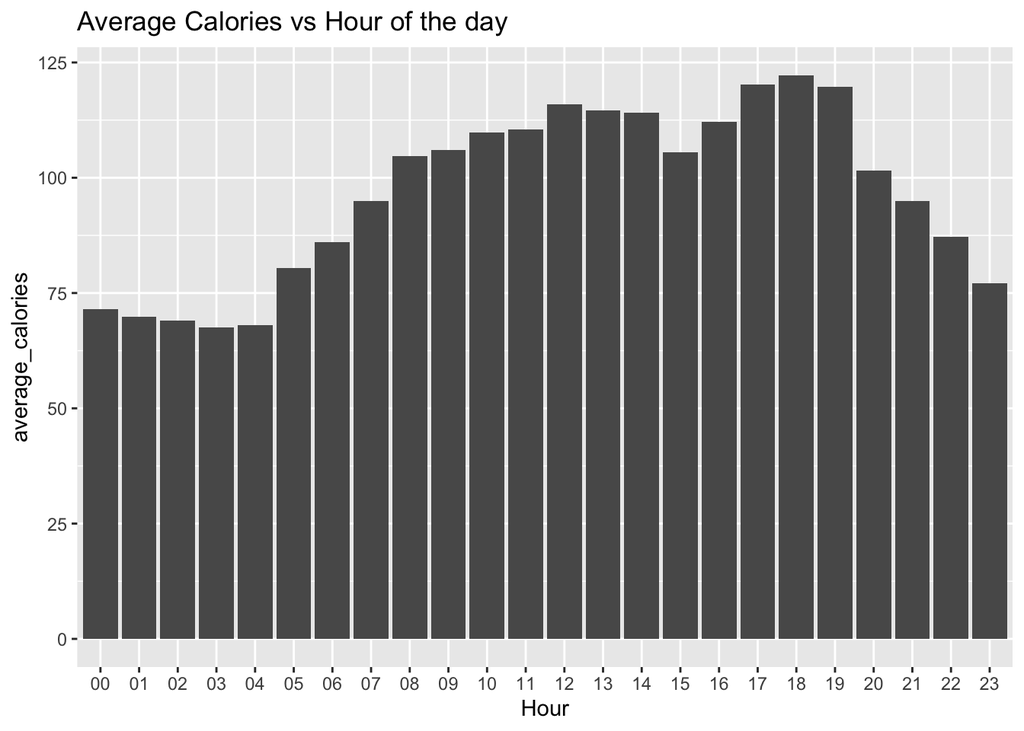

```r
ggplot(hourly_general, aes(x=Hour, y=average_calories)) +
  geom_bar(stat = "identity") +
  labs(title = "Average Calories vs Hour of the day")
```

##### These graphs show us the hours when users are most active. FitBit can leverage this isnsight and send psuh notifications to users to remind and encourage them about workout (go for a walk or run) during these hours. Peak activity is observed between *5pm and 7pm.*

# Step 5: Share